# Lab_08T

## Question 4

Install and load the `pROC` package, and plot ROC curves for both logistic regression and random forest. (Google the documentation for the `pROC` package to see how to do this; basically, call the `roc()` function and pass its output to `plot()`. In order to put both curves on the same plot: call `plot()` once, then call `plot()` again with the argument `add=TRUE`. This adds a curve to an existing plot. Also, to tell the curves apart: make them different colors. If you want to be adventurous: add a `legend()`.) For logistic regression, use the class probabilities that you get by calling `predict()` with `type="response"`, whereas for random forest, call `predict()` with `type="prob"`, *then* extract the *second* column. Which model has the best AUC? (Try examining the output from `roc()` to determine this. Remember `names()`?)

Note: to extract numerical probabilities for class 1 for logistic regression and for random forest, use the following.

```
resp.pred.log = predict(log.out,newdata=pred.test,type="response")
resp.pred.rf  = predict(rf.out,newdata=pred.test,type="prob")[,2]
```

```r
resp.pred.rf  = predict(rf.out,newdata=test,type="prob")[,2]

library(pROC)
roc.glm = roc(test$response, predicted)
```

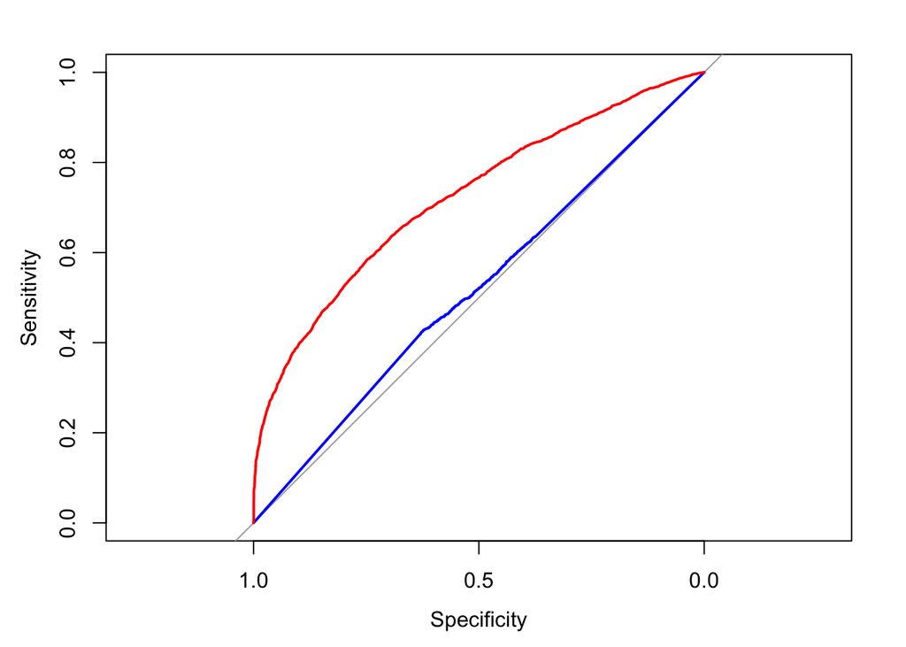

```r
plot(roc.glm, col="blue")

roc.random = roc(test$response, resp.pred.rf)
plot(roc.random,add=TRUE, col="red")
```

```r
roc.random$auc
```

```
## Area under the curve: 0.7222
```

```r
roc.glm$auc
```

```
## Area under the curve: 0.5174
```

```
random forest has greater AUC
```

## Question 5

There are many ways to determine what the optimum class-separation threshold would be for any given analysis. One way that is based directly on ROC curves is to determine which threshold maximizes Youden’s $J$ statistic: $J$ = `specificity` + `sensitivity` - 1. (Basically, it gives the same cost to misspecification and to missensitivity…it is what you use if you seek accuracy in both classes simultaneously.) For random forest, determine which threshold value maximizes Youden’s $J$ statistic. (The object output by `roc()` contains all the information you need!) In retrospect, are you surprised by the value? Is specificity or sensitivity higher?

```r
names(roc.random)
```

```
##  [1] "percent"            "sensitivities"      "specificities"
##  [4] "thresholds"         "direction"          "cases"
##  [7] "controls"           "fun.sesp"           "auc"
## [10] "call"               "original.predictor" "original.response"
## [13] "predictor"          "response"           "levels"
```

```r
roc.random$auc
```

```
## Area under the curve: 0.7222
```

```r
roc.glm$auc
```

```
## Area under the curve: 0.5174
```

```r
rf.sensitive = roc.random$sensitivities
rf.specific = roc.random$specificities

coords(roc.random, "best", ret="threshold", transpose = FALSE)
```

```
##   threshold
## 1     0.537
```

```r
J = rf.specific + rf.sensitive -1

index = max(J)
```

```
rf.specific + rf.sensitive= 1.3323978
 J = 0.3323978
 Optimal threshold= .537
 Sensitivity higher
```